# Udacity Machine Learning Nanodegree Capstone Project

The challenge for this project is to build a model, which can calculate and predict the price of real estate based on data collected in Melbourne. This problem will be solved in two different ways:

1. Building regression models using scikit learn library
2. Building neural net using keras library

# Solution #1: Regression models

## 1. Load data

### 1.1 Load libraries

```python
#Load libraries
import pandas as pd
import numpy as np
from time import time
import matplotlib.pyplot as plt
import seaborn as sns
import random
import tensorflow as tf

from sklearn.metrics import r2_score, mean_squared_error
from sklearn.model_selection import train_test_split
from sklearn.model_selection import KFold
from sklearn.model_selection import cross_val_score
from sklearn.model_selection import GridSearchCV
from sklearn.model_selection import RandomizedSearchCV
from sklearn.preprocessing import MinMaxScaler
from sklearn.preprocessing import LabelEncoder

from sklearn.tree import DecisionTreeRegressor
from sklearn.neighbors import KNeighborsRegressor
from sklearn.cross_decomposition import PLSRegression
from sklearn.ensemble import GradientBoostingRegressor
from sklearn.ensemble import RandomForestRegressor
from sklearn.ensemble import AdaBoostRegressor
from sklearn.ensemble import ExtraTreesRegressor
from sklearn.linear_model import LogisticRegression
from sklearn.linear_model import BayesianRidge
from sklearn.linear_model import HuberRegressor
from xgboost import XGBRegressor

from keras.models import Sequential
from keras.layers import Dense
from keras.layers import Dropout
from keras.callbacks import EarlyStopping
from keras.models import load_model
from keras import regularizers
from keras.models import model_from_yaml
from keras import backend as K

# Setting random state
random.seed(42)
np.random.seed(43)
sns.set(color_codes=True)
tf.set_random_seed(44)
session_conf = tf.ConfigProto(intra_op_parallelism_threads=1, inter_op_parallelism_threads=1)
sess = tf.Session(graph=tf.get_default_graph(), config = session_conf)
K.set_session(sess)
```

### 1.2 Helpful functions

```python
# Calculating and plotiing feature importance based on RandomForestRegressor
def model_run(dataframe):
    X_try_clean = dataframe.drop('Price', axis=1)
    y_try_clean = dataframe.Price
    X_try_train_clean, X_try_test_clean, y_try_train_clean, y_try_test_clean = train_test_split(X_try_clean, y_try_clean, test_size=0.2, random_state= 42)
    feat_reg = RandomForestRegressor(n_estimators=100)
    time_start = time()
    feat_reg.fit(X_try_train_clean,y_try_train_clean)
    y_pred = feat_reg.predict(X_try_test_clean)
    print('Fit-predict time: {:.3f} sec'.format(time()-time_start))
    print('RMSE: {:.3f}'.format(np.sqrt(mean_squared_error(y_try_test_clean, y_pred))))
    print('Score: {:.3f}'.format(feat_reg.score(X_try_test_clean, y_try_test_clean)))
    plt.figure(figsize=(15,10))
    plt.bar(dataframe.drop('Price', axis=1).columns,feat_reg.feature_importances_)
    plt.xticks(rotation=90)
    plt.ylabel('Feature importance')
    plt.savefig('fig5.jpeg')
    plt.show()

# Converts all missing values in the specified column to the median
def missing_median(df, name):
    med = df[name].median()
    df[name] = df[name].fillna(med)

#Loss plot
def plotting_loss(history):
    plt.figure(figsize=(15,10))
    plt.plot(history.history['loss'], lw=2)
    plt.plot(history.history['val_loss'], lw=2)
    plt.title('model loss')
    plt.ylabel('loss')
    plt.xlabel('epoch')
    plt.legend(['train', 'validation'], loc='best')
    #plt.ylim(0, 4*1e11)
    plt.show()

# Regression plot
def chart_regression(pred,y,sort=True):
    df = pd.DataFrame({'pred' : pred, 'y' : y})
    if sort:
        df.sort_values(by=['y'],inplace=True)
    plt.figure(figsize=(15,10))
    a = plt.plot(df['y'].tolist(),lw=5, label='expected')
    b = plt.plot(df['pred'].tolist(),lw=1, alpha=0.7,label='prediction')
    plt.ylabel('Price')
    plt.xlabel('number of testing datapoints')
    plt.legend()
    plt.show()

# RMSE plot
def plot_history(hist):
    plt.figure(figsize=(15,10))
    plt.xlabel('Epoch')
    plt.ylabel('Root Mean Square Error')
    plt.plot(hist['epoch'], np.sqrt(hist['mean_squared_error']),
           label='Train Error')
    plt.plot(hist['epoch'], np.sqrt(hist['val_mean_squared_error']),
           label = 'Val Error')
    plt.legend()
    plt.show()
```

### 1.3 Reading data from CSV

```python
# Load data from SCV
data = pd.read_csv('melb_data.csv')
```

```python
print(f'The imported data has {data.shape[0]} rows and {data.shape[1]} columns')
```

```
The imported data has 13580 rows and 21 columns
```

```python
# Printing out the first 5 rows to see what kind of data we working with
data.head()
```

|  | Suburb | Address | Rooms | Type | Price | Method | SellerG | Date | Distance | Postcode | ... | Bathroom | Car | Landsize | BuildingArea | YearBuilt | CouncilArea | Lattitude | Longtitude | Regionname | Propertycount |
| --- | --- | --- | --- | --- | --- | --- | --- | --- | --- | --- | --- | --- | --- | --- | --- | --- | --- | --- | --- | --- | --- |
| 0 | Abbotsford | 85 Turner St | 2 | h | 1480000.0 | S | Biggin | 3/12/2016 | 2.5 | 3067.0 | ... | 1.0 | 1.0 | 202.0 | NaN | NaN | Yarra | -37.7996 | 144.9984 | Northern Metropolitan | 4019.0 |
| 1 | Abbotsford | 25 Bloomburg St | 2 | h | 1035000.0 | S | Biggin | 4/02/2016 | 2.5 | 3067.0 | ... | 1.0 | 0.0 | 156.0 | 79.0 | 1900.0 | Yarra | -37.8079 | 144.9934 | Northern Metropolitan | 4019.0 |
| 2 | Abbotsford | 5 Charles St | 3 | h | 1465000.0 | SP | Biggin | 4/03/2017 | 2.5 | 3067.0 | ... | 2.0 | 0.0 | 134.0 | 150.0 | 1900.0 | Yarra | -37.8093 | 144.9944 | Northern Metropolitan | 4019.0 |
| 3 | Abbotsford | 40 Federation La | 3 | h | 850000.0 | PI | Biggin | 4/03/2017 | 2.5 | 3067.0 | ... | 2.0 | 1.0 | 94.0 | NaN | NaN | Yarra | -37.7969 | 144.9969 | Northern Metropolitan | 4019.0 |
| 4 | Abbotsford | 55a Park St | 4 | h | 1600000.0 | VB | Nelson | 4/06/2016 | 2.5 | 3067.0 | ... | 1.0 | 2.0 | 120.0 | 142.0 | 2014.0 | Yarra | -37.8072 | 144.9941 | Northern Metropolitan | 4019.0 |

5 rows × 21 columns

```python
# Statistical information about the dataset
data.describe()
```

|  | Rooms | Price | Distance | Postcode | Bedroom | Bathroom | Car | Landsize | BuildingArea | YearBuilt | Lattitude | Longtitude | Propertycount |
| --- | --- | --- | --- | --- | --- | --- | --- | --- | --- | --- | --- | --- | --- |
| count | 13580.000000 | 1.358000e+04 | 13580.000000 | 13580.000000 | 13580.000000 | 13580.000000 | 13518.000000 | 13580.000000 | 7130.000000 | 8205.000000 | 13580.000000 | 13580.000000 | 13580.000000 |
| mean | 2.937997 | 1.075684e+06 | 10.137776 | 3105.301915 | 2.914728 | 1.534242 | 1.610075 | 558.416127 | 151.967650 | 1964.684217 | -37.809203 | 144.995216 | 7454.417378 |
| std | 0.955748 | 6.393107e+05 | 5.868725 | 90.676964 | 0.965921 | 0.691712 | 0.962634 | 3990.669241 | 541.014538 | 37.273762 | 0.079260 | 0.103916 | 4378.581772 |
| min | 1.000000 | 8.500000e+04 | 0.000000 | 3000.000000 | 0.000000 | 0.000000 | 0.000000 | 0.000000 | 0.000000 | 1196.000000 | -38.182550 | 144.431810 | 249.000000 |
| 25% | 2.000000 | 6.500000e+05 | 6.100000 | 3044.000000 | 2.000000 | 1.000000 | 1.000000 | 177.000000 | 93.000000 | 1940.000000 | -37.856822 | 144.929600 | 4380.000000 |
| 50% | 3.000000 | 9.030000e+05 | 9.200000 | 3084.000000 | 3.000000 | 1.000000 | 2.000000 | 440.000000 | 126.000000 | 1970.000000 | -37.802355 | 145.000100 | 6555.000000 |
| 75% | 3.000000 | 1.330000e+06 | 13.000000 | 3148.000000 | 3.000000 | 2.000000 | 2.000000 | 651.000000 | 174.000000 | 1999.000000 | -37.756400 | 145.058305 | 10331.000000 |
| max | 10.000000 | 9.000000e+06 | 48.100000 | 3977.000000 | 20.000000 | 8.000000 | 10.000000 | 433014.000000 | 44515.000000 | 2018.000000 | -37.408530 | 145.526350 | 21650.000000 |

## 2. Data preprocessing

### 2.1 Missing values, unique values, duplicates

```python
# Duplicates (rows)
print(f'The number of duplicated rows: {data.duplicated().sum()}')
```

```
The number of duplicated rows: 0
```

```python
data.isnull().sum()
```

```
Suburb              0
Address             0
Rooms               0
Type                0
Price               0
Method              0
SellerG             0
Date                0
Distance            0
Postcode            0
Bedroom             0
Bathroom            0
Car                62
Landsize            0
BuildingArea     6450
YearBuilt        5375
CouncilArea      1369
Lattitude           0
Longtitude          0
Regionname          0
Propertycount       0
dtype: int64
```

```python
# Missing values
print('The total number of missing values in each column in %:')
data.isnull().sum()*100/data.shape[0]
```

```
The total number of missing values in each column in %:
```

```
Suburb            0.000000
Address           0.000000
Rooms             0.000000
Type              0.000000
Price             0.000000
Method            0.000000
SellerG           0.000000
Date              0.000000
Distance          0.000000
Postcode          0.000000
Bedroom           0.000000
Bathroom          0.000000
Car               0.456554
Landsize          0.000000
BuildingArea     47.496318
YearBuilt        39.580265
CouncilArea      10.081001
Lattitude         0.000000
Longtitude        0.000000
Regionname        0.000000
Propertycount     0.000000
dtype: float64
```

```python
# The number of unique values in each column. Important for LabelEncoding or One-Hot-Encoding
for col in data.columns:
    print('The number of unique elements in column {}: {}'.format(col, data[col].unique().shape[0]))
```

```
The number of unique elements in column Suburb: 314
The number of unique elements in column Address: 13378
The number of unique elements in column Rooms: 9
The number of unique elements in column Type: 3
The number of unique elements in column Price: 2204
The number of unique elements in column Method: 5
The number of unique elements in column SellerG: 268
The number of unique elements in column Date: 58
The number of unique elements in column Distance: 202
The number of unique elements in column Postcode: 198
The number of unique elements in column Bedroom: 12
The number of unique elements in column Bathroom: 9
The number of unique elements in column Car: 12
The number of unique elements in column Landsize: 1448
The number of unique elements in column BuildingArea: 603
The number of unique elements in column YearBuilt: 145
The number of unique elements in column CouncilArea: 34
The number of unique elements in column Lattitude: 6503
The number of unique elements in column Longtitude: 7063
The number of unique elements in column Regionname: 8
The number of unique elements in column Propertycount: 311
```

```python
# Dropping columns
data.drop(['Address', 'YearBuilt', 'CouncilArea', 'BuildingArea', 'Date', 'Suburb', 'SellerG'], axis=1, inplace=True)
```

```python
# Handling NaN in column Car
missing_median(data,'Car')
```

### 2.2 Inversigating of cross correlation

```python
# Create correlation matrix
corr_matrix=data.corr().abs()

# Select upper triangle of correlation matrix
upper = corr_matrix.where(np.triu(np.ones(corr_matrix.shape), k=1).astype(np.bool))

# Find index of feature columns with correlation greater than 0.95
to_drop = [column for column in upper.columns if any(upper[column] > 0.95)]
print('List of columns which must be dropped due to high cross-correlation with other columns: {}'.format(to_drop))
```

```
List of columns which must be dropped due to high cross-correlation with other columns: []
```

```python
# Iversigating correlation matrix
corr_matrix
```

|  | Rooms | Price | Distance | Postcode | Bedroom | Bathroom | Car | Landsize | Lattitude | Longtitude | Propertycount |
| --- | --- | --- | --- | --- | --- | --- | --- | --- | --- | --- | --- |
| Rooms | 1.000000 | 0.496634 | 0.294203 | 0.055303 | 0.944190 | 0.592934 | 0.406935 | 0.025678 | 0.015948 | 0.100771 | 0.081530 |
| Price | 0.496634 | 1.000000 | 0.162522 | 0.107867 | 0.475951 | 0.467038 | 0.239109 | 0.037507 | 0.212934 | 0.203656 | 0.042153 |
| Distance | 0.294203 | 0.162522 | 1.000000 | 0.431514 | 0.295927 | 0.127155 | 0.260596 | 0.025004 | 0.130723 | 0.239425 | 0.054910 |
| Postcode | 0.055303 | 0.107867 | 0.431514 | 1.000000 | 0.060584 | 0.113664 | 0.050514 | 0.024558 | 0.406104 | 0.445357 | 0.062304 |
| Bedroom | 0.944190 | 0.475951 | 0.295927 | 0.060584 | 1.000000 | 0.584685 | 0.403867 | 0.025646 | 0.015925 | 0.102238 | 0.081350 |
| Bathroom | 0.592934 | 0.467038 | 0.127155 | 0.113664 | 0.584685 | 1.000000 | 0.321014 | 0.037130 | 0.070594 | 0.118971 | 0.052201 |
| Car | 0.406935 | 0.239109 | 0.260596 | 0.050514 | 0.403867 | 0.321014 | 1.000000 | 0.026780 | 0.002023 | 0.062929 | 0.024344 |
| Landsize | 0.025678 | 0.037507 | 0.025004 | 0.024558 | 0.025646 | 0.037130 | 0.026780 | 1.000000 | 0.009695 | 0.010833 | 0.006854 |
| Lattitude | 0.015948 | 0.212934 | 0.130723 | 0.406104 | 0.015925 | 0.070594 | 0.002023 | 0.009695 | 1.000000 | 0.357634 | 0.047086 |
| Longtitude | 0.100771 | 0.203656 | 0.239425 | 0.445357 | 0.102238 | 0.118971 | 0.062929 | 0.010833 | 0.357634 | 1.000000 | 0.065988 |
| Propertycount | 0.081530 | 0.042153 | 0.054910 | 0.062304 | 0.081350 | 0.052201 | 0.024344 | 0.006854 | 0.047086 | 0.065988 | 1.000000 |

### 2.3 Exploring dependencies between price and features

For better understanding of dependencies between target variable and each feature the data will be divided ino two groups

#### 2.3.1 Exploring the Group #1

The first group consist of following columns: Type, Method, Rooms, Bedroom, Bathroom, Car.

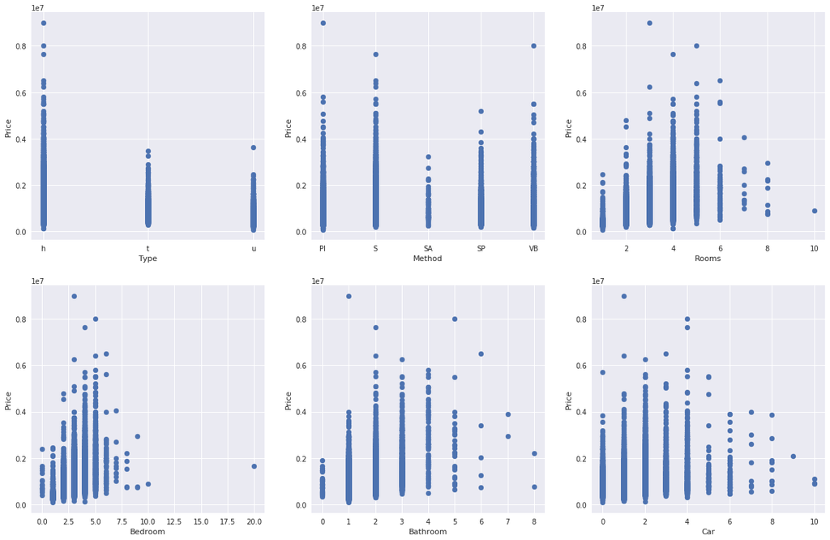

```python
#Plotting dependencies between price and feature
fig = plt.figure(figsize=(20,20))

plt.subplot(331)
plt.scatter(data.Type, data.Price)
plt.xlabel('Type')
plt.ylabel('Price')

plt.subplot(332)
plt.scatter(data.Method, data.Price)
plt.xlabel('Method')
plt.ylabel('Price')

plt.subplot(333)
plt.scatter(data.Rooms, data.Price)
plt.xlabel('Rooms')
plt.ylabel('Price')

plt.subplot(334)
plt.scatter(data.Bedroom, data.Price)
plt.xlabel('Bedroom')
plt.ylabel('Price')

plt.subplot(335)
plt.scatter(data.Bathroom, data.Price)
plt.xlabel('Bathroom')
plt.ylabel('Price')

plt.subplot(336)
plt.scatter(data.Car, data.Price)
plt.xlabel('Car')
plt.ylabel('Price')

plt.show()
```

#### 2.3.2 Exploring the Group #2

The second group consist of following columns: Postcode, Distance, Lattitude, Longtitude, Propertycount, Landsize

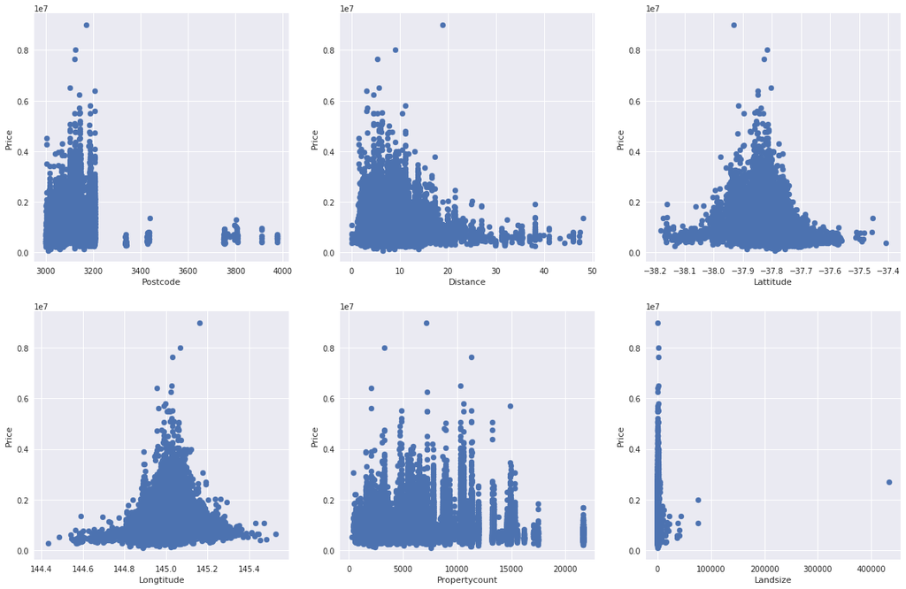

```python
#Plotting dependencies between price and feature
fig = plt.figure(figsize=(20,20))

plt.subplot(331)
plt.scatter(data.Postcode, data.Price)
plt.xlabel('Postcode')
plt.ylabel('Price')

plt.subplot(332)
plt.scatter(data.Distance, data.Price)
plt.xlabel('Distance')
plt.ylabel('Price')

plt.subplot(333)
plt.scatter(data.Lattitude, data.Price)
plt.xlabel('Lattitude')
plt.ylabel('Price')

plt.subplot(334)
plt.scatter(data.Longtitude, data.Price)
plt.xlabel('Longtitude')
plt.ylabel('Price')

plt.subplot(335)
plt.scatter(data.Propertycount, data.Price)
plt.xlabel('Propertycount')
plt.ylabel('Price')

plt.subplot(336)
plt.scatter(data.Landsize, data.Price)
plt.xlabel('Landsize')
plt.ylabel('Price')

plt.show()
```

```python
le = LabelEncoder()
data.Postcode = le.fit_transform(data.Postcode)
data.Propertycount = le.fit_transform(data.Propertycount)
```

### 2.3.3 Distribution of values

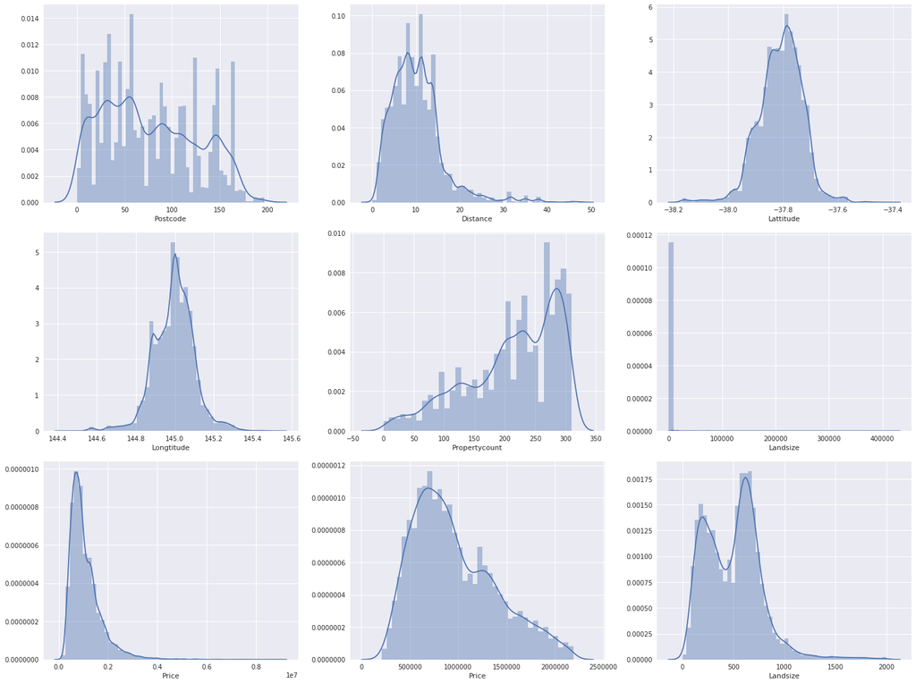

```python
# Distribution

fig = plt.figure(figsize=(20,15))

ax1 = fig.add_subplot(331)
ax1 = sns.distplot(data.Postcode, bins=50)

ax2 = fig.add_subplot(332)
ax2 = sns.distplot(data.Distance)

ax3 = fig.add_subplot(333)
ax3 = sns.distplot(data.Lattitude)


ax4 = fig.add_subplot(334)
ax4 = sns.distplot(data.Longtitude)

ax5 = fig.add_subplot(335)
ax5 = sns.distplot(data.Propertycount)

ax6 = fig.add_subplot(336)
ax6 = sns.distplot(data.Landsize)

ax7 = fig.add_subplot(337)
ax7 = sns.distplot(data.Price)

ax8 = fig.add_subplot(338)
ax8 = sns.distplot(data.Price[(data.Price>.2*1e6)&(data.Price<2.2*1e6)])

ax9 = fig.add_subplot(339)
ax9 = sns.distplot(data.Landsize[(data.Landsize>0)&(data.Landsize<2000)])

plt.tight_layout()
plt.show()
```

### 2.3.4 Handling outliers

```python
# Handling outliers
print(f'Shape of initial DataFrame: {data.shape}')
#data = data[(data.Price>.25*1e6)&(data.Price<2.3*1e6)]
data = data[(data.Price>.2*1e6)&(data.Price<2.2*1e6)]
data = data[(data.Landsize>0)&(data.Landsize<=1500)]
print(f'Shape of DataFrame after dropping outliers: {data.shape}')
```

```
Shape of initial DataFrame: (13580, 14)
Shape of DataFrame after dropping outliers: (10546, 14)
```

```python
# Make copy of the cleaned data
final_data = data.copy()
```

### 2.3.5 One hot encoding

```python
# One hot encoding of Type, Regionname and Method columns
data = pd.get_dummies(data, columns=['Type', 'Regionname', 'Method'])
```

### 2.3.6 Investigating feature importance

Using RandomForestRegressor and it's attribute feature_importances let's find the columns which impact the calculations the most in order to reduce the model complexity and calculating time

```
Fit-predict time: 5.108 sec
RMSE: 178440.788
Score: 0.816
```

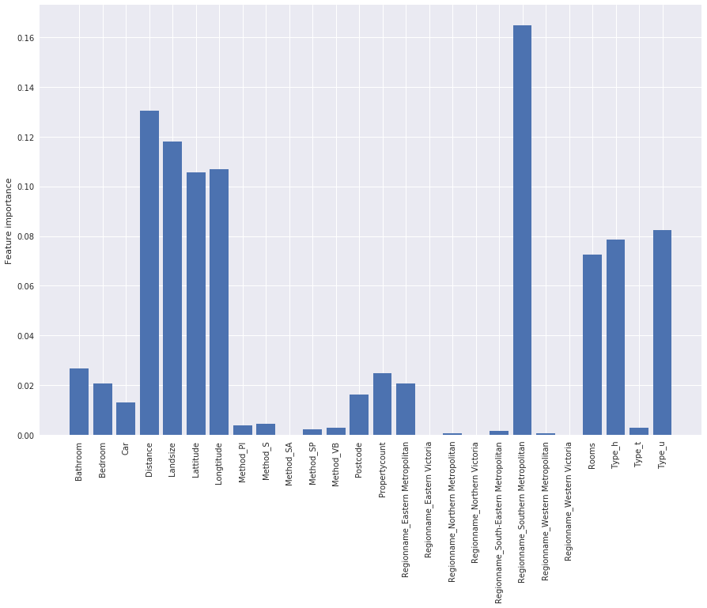

```python
# Run testfunc on full data to find the most important features
model_run(data)
```

We will drop a columns which impact is less than 4%

```python
# Dropping features wich less impact the target
data_clnd = data.drop(['Bathroom', 'Bedroom', 'Car', 'Propertycount','Postcode', 'Type_t', 'Regionname_Eastern Metropolitan',
       'Regionname_Eastern Victoria', 'Regionname_Northern Metropolitan',
       'Regionname_Northern Victoria', 'Regionname_South-Eastern Metropolitan',  'Regionname_Western Metropolitan', 'Regionname_Western Victoria',
       'Method_PI', 'Method_S', 'Method_SA', 'Method_SP', 'Method_VB'], axis=1)
```

```
Fit-predict time: 3.062 sec
RMSE: 188239.998
Score: 0.795
```

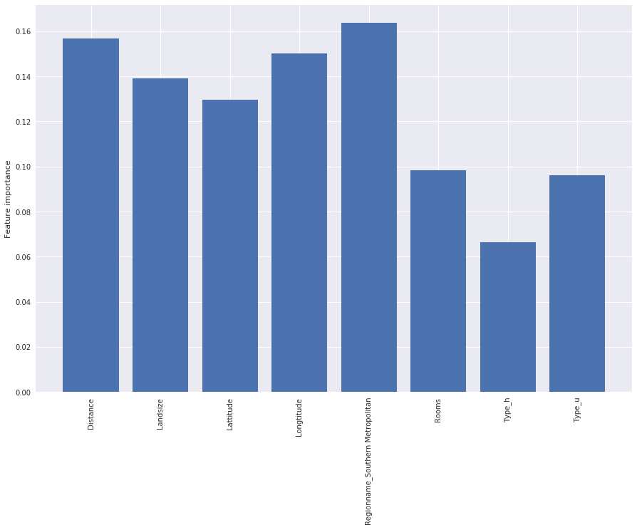

```python
# Re-Run testfunc on cleaned data
model_run(data_clnd)
```

### 2.4 Training and testing sets

```python
data_clnd.head()
```

|  | Rooms | Price | Distance | Landsize | Lattitude | Longtitude | Type_h | Type_u | Regionname_Southern Metropolitan |
| --- | --- | --- | --- | --- | --- | --- | --- | --- | --- |
| 0 | 2 | 1480000.0 | 2.5 | 202.0 | -37.7996 | 144.9984 | 1 | 0 | 0 |
| 1 | 2 | 1035000.0 | 2.5 | 156.0 | -37.8079 | 144.9934 | 1 | 0 | 0 |
| 2 | 3 | 1465000.0 | 2.5 | 134.0 | -37.8093 | 144.9944 | 1 | 0 | 0 |
| 3 | 3 | 850000.0 | 2.5 | 94.0 | -37.7969 | 144.9969 | 1 | 0 | 0 |
| 4 | 4 | 1600000.0 | 2.5 | 120.0 | -37.8072 | 144.9941 | 1 | 0 | 0 |

```python
# Extracting features and target
y = data_clnd.Price.values.astype(np.float32)
X = data_clnd.drop('Price', axis=1).values.astype(np.float32)
```

```python
# Scaling feature data into range (0,1)
scaler = MinMaxScaler()
X = scaler.fit_transform(X)
```

```python
test_df = pd.DataFrame(X, columns=data_clnd.drop('Price', axis=1).columns)
```

```python
test_df.head()
```

|  | Rooms | Distance | Landsize | Lattitude | Longtitude | Type_h | Type_u | Regionname_Southern Metropolitan |
| --- | --- | --- | --- | --- | --- | --- | --- | --- |
| 0 | 0.111111 | 0.052743 | 0.135081 | 0.485088 | 0.517654 | 1.0 | 0.0 | 0.0 |
| 1 | 0.111111 | 0.052743 | 0.104167 | 0.474159 | 0.513077 | 1.0 | 0.0 | 0.0 |
| 2 | 0.222222 | 0.052743 | 0.089382 | 0.472317 | 0.513992 | 1.0 | 0.0 | 0.0 |
| 3 | 0.222222 | 0.052743 | 0.062500 | 0.488640 | 0.516281 | 1.0 | 0.0 | 0.0 |
| 4 | 0.333333 | 0.052743 | 0.079973 | 0.475079 | 0.513718 | 1.0 | 0.0 | 0.0 |

```python
# Splitting the data into training and testing set. 20% of data for testing set
X_main, X_holdout, y_main, y_holdout = train_test_split(X, y, test_size=0.2, random_state= 42)
```

```python
print(f'The training set of the features consist of {X_main.shape[0]} rows and {X_main.shape[1]} columns')
print(f'The testing set of the features consist of {X_holdout.shape[0]} rows and {X_holdout.shape[1]} columns')
print(f'The training set of the target consist of {y_main.shape[0]} items')
print(f'The training set of the target consist of {y_holdout.shape[0]} items')
```

```
The training set of the features consist of 8436 rows and 8 columns
The testing set of the features consist of 2110 rows and 8 columns
The training set of the target consist of 8436 items
The training set of the target consist of 2110 items
```

### 2.5 Benchmark model

```python
from sklearn.linear_model import LinearRegression
bench_mod = LinearRegression().fit(X_main, y_main)
bench_mod_score = bench_mod.score(X_holdout, y_holdout)
y_pred_bench_mod = bench_mod.predict(X_holdout)
bench_mod_rmse = np.sqrt(mean_squared_error(y_holdout, y_pred_bench_mod))
print('Score of the benchmark model: {:.3f}'.format(bench_mod_score))
print('RMSE of the benchmark model: {:.3f}'.format(bench_mod_rmse))
```

```
Score of the benchmark model: 0.593
RMSE of the benchmark model: 264926.625
```

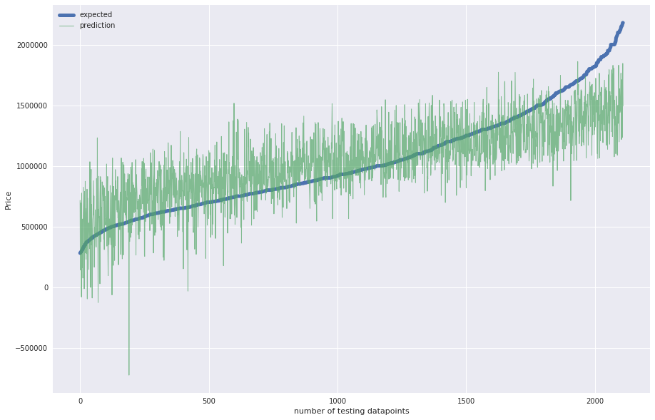

```python
chart_regression(y_pred_bench_mod, y_holdout)
```

## 3. Exploring regression models

### 3.1 Trainig methods and evaluation metrics

### Mean Square Error

The mean square error is the sum of the squared differences between the prediction ($\hat{y}$) and the expected ($y$). MSE values are not of a particular unit. Low MSE values are desired.

$\text{MSE} = \frac{1}{n} \sum_{i=1}^n \left(\hat{y}_i - y_i\right)^2$

### Root Mean Square Error

The root mean square (RMSE) is essentially the square root of the MSE. Because of this, the RMSE error is in the same units as the training data outcome. Low RMSE values are desired.

$\text{RMSE} = \sqrt{\frac{1}{n} \sum_{i=1}^n \left(\hat{y}_i - y_i\right)^2}$

### Training with Cross-Validation and holdout set

Cross-Validation uses a number of folds, and multiple models, to generate out of sample predictions on the entire dataset. In this case there will be one model (neural network) for each fold. Each model contributes part of the final out-of-sample prediction.

[figure not shown]

### 3.2 Investigating different regression models

In this section the best predictive model will be chosen between following models from scikit learn library:

- DecisionTreeRegressor
- GradientBoostingRegressor
- RandomForestRegressor
- KNeighborsRegressor
- PLSRegression
- BayesianRidge
- HuberRegressor
- ExtraTreesRegressor
- AdaBoostRegressor
- XGBRegressor

```python
# Suppressing future warnings
import warnings
warnings.simplefilter(action='ignore', category=FutureWarning)

# model inititlizing
clf_A = DecisionTreeRegressor()
clf_B = GradientBoostingRegressor()
clf_C = RandomForestRegressor()
clf_D = KNeighborsRegressor()
clf_E = PLSRegression()
clf_F = BayesianRidge()
clf_G = HuberRegressor(max_iter=1e4)
clf_H = ExtraTreesRegressor()
clf_I = AdaBoostRegressor()
clf_J = XGBRegressor()


# list initilizing
results=[]
alg=[]
time_l=[]
rmse_l=[]

# Looping over each model and calculating the cross validation score, calculation time and RMSE
for clf in [clf_A, clf_B,clf_C,clf_D,clf_E,clf_F,clf_G,clf_H,clf_I,clf_J]:
    # list of cross validation scores
    cv_results = cross_val_score(clf, X_main, y_main, cv = 5, scoring = 'r2')
    results.append(cv_results)
    start=time()
    clf = clf.fit(X_main, y_main)
    y_pred = clf.predict(X_holdout)
    end=time()
    alg.append(clf.__class__.__name__)
    # list of calculation times
    time_l.append(end-start)
    #computing RMSE
    rmse = np.sqrt(mean_squared_error(y_holdout, y_pred))
    rmse_l.append(rmse)
    msg = "{:25} --> cross_val_score: {:.3f}, RMSE: {:.3f} in {:.3f} sec".format(clf.__class__.__name__, cv_results.mean(), rmse, end-start)
    print(msg)
    print(80*'=')
```

```
DecisionTreeRegressor     --> cross_val_score: 0.605, RMSE: 262938.550 in 0.046 sec
================================================================================
GradientBoostingRegressor --> cross_val_score: 0.751, RMSE: 207075.767 in 0.408 sec
================================================================================
RandomForestRegressor     --> cross_val_score: 0.773, RMSE: 196323.399 in 0.308 sec
================================================================================
KNeighborsRegressor       --> cross_val_score: 0.737, RMSE: 209380.641 in 0.089 sec
================================================================================
PLSRegression             --> cross_val_score: 0.575, RMSE: 272572.751 in 0.004 sec
================================================================================
BayesianRidge             --> cross_val_score: 0.587, RMSE: 264948.768 in 0.004 sec
================================================================================
HuberRegressor            --> cross_val_score: 0.549, RMSE: 277665.674 in 0.061 sec
================================================================================
ExtraTreesRegressor       --> cross_val_score: 0.763, RMSE: 202382.922 in 0.169 sec
================================================================================
AdaBoostRegressor         --> cross_val_score: 0.518, RMSE: 289409.756 in 0.434 sec
================================================================================
XGBRegressor              --> cross_val_score: 0.753, RMSE: 207075.969 in 0.475 sec
================================================================================
```

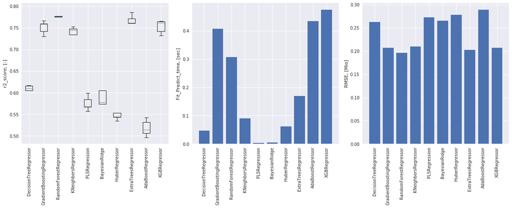

```python
# Compare models
fig, (ax1,ax2,ax3) = plt.subplots(1,3, figsize=(17,7))

ax1.set_ylabel('r2_score, [-]')
ax1.boxplot(results)
ax1.set_xticklabels(alg, rotation=90)

y_pos = range(len(time_l))
ax2.set_ylabel('Fit_Predict_time, [sec]')
ax2.bar(y_pos, time_l, align='center')
ax2.set_xticks(y_pos)
ax2.set_xticklabels(alg,rotation=90)

ax3.set_ylabel('RMSE, [Mio]')
ax3.bar(y_pos, np.array(rmse_l)/1e6, align='center')
ax3.set_xticks(y_pos)
ax3.set_xticklabels(alg,rotation=90)

plt.tight_layout()
plt.show()
```

The best models are:

- **GradientBoostingRegressor**
- **RandomForestRegressor**
- **ExtraTreesRegressor**
- **XGBRegressor**

### 3.3 Tuning the hyperparameters

```python
#Defining a function to find better hyperparameters for the model
def model_opt(X_train,y_train,X_test,y_test,reg,par,scorer='r2',cv=5):
    """ Performs grid search over the different parameter for a
        given regressor trained on the input data [X_train, y_train]. """
    grid = RandomizedSearchCV(reg, par, scoring=scorer, cv=cv, n_jobs=-1, n_iter=20)
    grid = grid.fit(X_train,y_train)
    model = grid.best_estimator_
    y_pred = model.predict(X_test)
    r_score = r2_score(y_test, y_pred)
    score_to_bm = 100*(bench_mod_score-r_score)/bench_mod_score
    rmse = np.sqrt(mean_squared_error(y_test, y_pred))
    rmse_to_bm = 100*(bench_mod_rmse-rmse)/bench_mod_rmse
    print('Best parameters of {} are: {}'.format(reg.__class__.__name__, grid.best_params_))
    print('r2_score of optimized {}: {:.3f}'.format(reg.__class__.__name__, r_score))
    print('Delta r_score to benchmar kmodel: {:.1f}%'.format(score_to_bm))
    print('RMSE of optimized {}: {:.3f}'.format(reg.__class__.__name__, rmse))
    print('Delta RMSE to benchmar kmodel: {:.1f}%'.format(rmse_to_bm))

    return y_pred, rmse, r_score
```

```python
# Hyperparamteres to tune with GridSearch
params = {'n_estimators': [100, 200, 300],
            'min_samples_split':[2,3,4,5,6,7,8],
            'min_samples_leaf':[2,3,4,5,6,7,8],
            'max_depth':[2,3,4,5,6,7,8]}

params_xgb = {'n_estimators': [100, 200, 300],
              'learning_rate': [0.001, 0.01, 0.1],
              'max_depth':[2,3,4,5,6,7,8]}

params_kn = {'n_neighbors': [2,3,4,5,6,7,8,9,10],
             'leaf_size': [10,20,30,40,50,60]}
```

```python
# Tuning the hyperparamteres for KNeighborsRegressor
y_pred_kn, rmse_kn, score_kn = model_opt(X_main, y_main, X_holdout, y_holdout, KNeighborsRegressor(), params_kn)
```

```
Best parameters of KNeighborsRegressor are: {'n_neighbors': 9, 'leaf_size': 40}
r2_score of optimized KNeighborsRegressor: 0.757
Delta r_score to benchmar kmodel: -27.6%
RMSE of optimized KNeighborsRegressor: 204767.031
Delta RMSE to benchmar kmodel: 22.7%
```

```python
# Tuning the hyperparamteres for GradientBoostingRegressor
y_pred_gbr, rmse_gbr, score_gbr = model_opt(X_main, y_main, X_holdout, y_holdout, GradientBoostingRegressor(random_state = 42), params)
```

```
Best parameters of GradientBoostingRegressor are: {'n_estimators': 100, 'min_samples_split': 3, 'min_samples_leaf': 7, 'max_depth': 8}
r2_score of optimized GradientBoostingRegressor: 0.800
Delta r_score to benchmar kmodel: -34.9%
RMSE of optimized GradientBoostingRegressor: 185577.497
Delta RMSE to benchmar kmodel: 30.0%
```

```python
# Tuning the hyperparamteres for XGBRegressor
y_pred_xgb, rmse_xgb, score_xgb = model_opt(X_main, y_main, X_holdout, y_holdout, XGBRegressor(random_state = 42), params_xgb)
```

```
Best parameters of XGBRegressor are: {'n_estimators': 200, 'max_depth': 6, 'learning_rate': 0.1}
r2_score of optimized XGBRegressor: 0.800
Delta r_score to benchmar kmodel: -34.8%
RMSE of optimized XGBRegressor: 185969.172
Delta RMSE to benchmar kmodel: 29.8%
```

```python
# Tuning the hyperparamteres for RandomForestRegressor
y_pred_rfr, rmse_rfr, score_rfr = model_opt(X_main, y_main, X_holdout, y_holdout, RandomForestRegressor(random_state = 42), params)
```

```
Best parameters of RandomForestRegressor are: {'n_estimators': 300, 'min_samples_split': 5, 'min_samples_leaf': 5, 'max_depth': 8}
r2_score of optimized RandomForestRegressor: 0.757
Delta r_score to benchmar kmodel: -27.6%
RMSE of optimized RandomForestRegressor: 204872.443
Delta RMSE to benchmar kmodel: 22.7%
```

```python
# Tuning the hyperparamteres for ExtraTreesRegressor
y_pred_etr, rmse_etr, score_etr = model_opt(X_main, y_main, X_holdout, y_holdout, ExtraTreesRegressor(random_state = 42), params)
```

```
Best parameters of ExtraTreesRegressor are: {'n_estimators': 300, 'min_samples_split': 2, 'min_samples_leaf': 3, 'max_depth': 8}
r2_score of optimized ExtraTreesRegressor: 0.687
Delta r_score to benchmar kmodel: -15.9%
RMSE of optimized ExtraTreesRegressor: 232248.944
Delta RMSE to benchmar kmodel: 12.3%
```

```python
# DataFrame with results of best regression models after tuning of hyperparameters
df_bestmod = pd.DataFrame({'r2_score': [score_kn,score_gbr, score_xgb, score_rfr, score_etr],
                           'rmse': [rmse_kn, rmse_gbr, rmse_xgb, rmse_rfr, rmse_etr]})
```

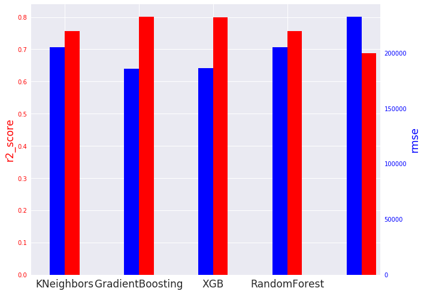

```python
# Create matplotlib figure
fig = plt.figure(figsize=(10,7))

# Create matplotlib axes
ax = fig.add_subplot(111)

# Create another axes that shares the same x-axis as ax.
ax2 = ax.twinx()

width = 0.2

df_bestmod.r2_score.plot(kind='bar', color='red', ax=ax, width=width, position=0, label='score')
df_bestmod.rmse.plot(kind='bar', color='blue', ax=ax2, width=width, position=1, label='rmse')

ax.set_ylabel('r2_score',  color='red', fontsize=17)
ax.tick_params('y', colors='red')
ax.tick_params('x', labelsize=17, rotation = 0)

ax2.set_ylabel('rmse', color='blue', fontsize=17)
ax2.tick_params('y', colors='blue')

plt.xticks(np.arange(4), ['KNeighbors','GradientBoosting', 'XGB', 'RandomForest', 'ExtraTrees'], rotation=90)
plt.grid(b=False)
plt.tight_layout()
plt.show()
```

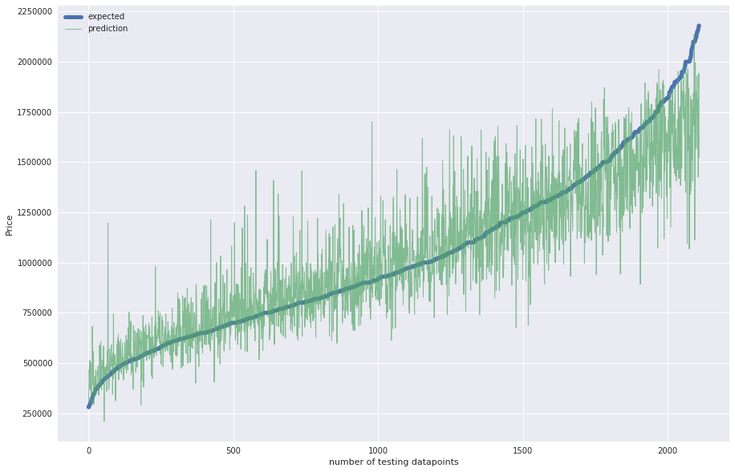

```python
# Plot of how XGBRegressor fits the data
chart_regression(y_pred_gbr, y_holdout)
```

### 3.4 Results and conclusion

```python
# DataFrafe with results of GradientBoostingRegressor before and after tuning of hyperparameters
df_gbr = pd.DataFrame({'cross_val_score':[0.751, score_gbr],
                  'rmse': [207075.767, rmse_gbr]},
                     index=['before tuning', 'after tuning'])
```

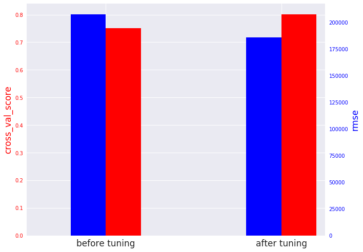

```python
# Create matplotlib figure
fig = plt.figure(figsize=(10,7))

# Create matplotlib axes
ax = fig.add_subplot(111)

# Create another axes that shares the same x-axis as ax.
ax2 = ax.twinx()

width = 0.2

df_gbr.cross_val_score.plot(kind='bar', color='red', ax=ax, width=width, position=0, label='score')
df_gbr.rmse.plot(kind='bar', color='blue', ax=ax2, width=width, position=1, label='rmse')

ax.set_ylabel('cross_val_score',  color='red', fontsize=17)
ax.tick_params('y', colors='red')
ax.tick_params('x', labelsize=17, rotation = 0)

ax2.set_ylabel('rmse', color='blue', fontsize=17)
ax2.tick_params('y', colors='blue')

plt.grid(b=False)
plt.tight_layout()
plt.savefig('fig9.jpeg')
plt.show()
```

# Solution 2: Neural net

## 4. Building the neural network

The second approach to predict the prices of real esate will be building of neural network. For this approach we will be using a cross validation technique with hold out set for final evaluating of the model on unseen data

### 4.1 Building and trainig the neural net on trainig set using K-Fold cross validation

```
Fold #1
Fold score (RMSE): 224199.172
Min score (RMSE): 224199.172
```

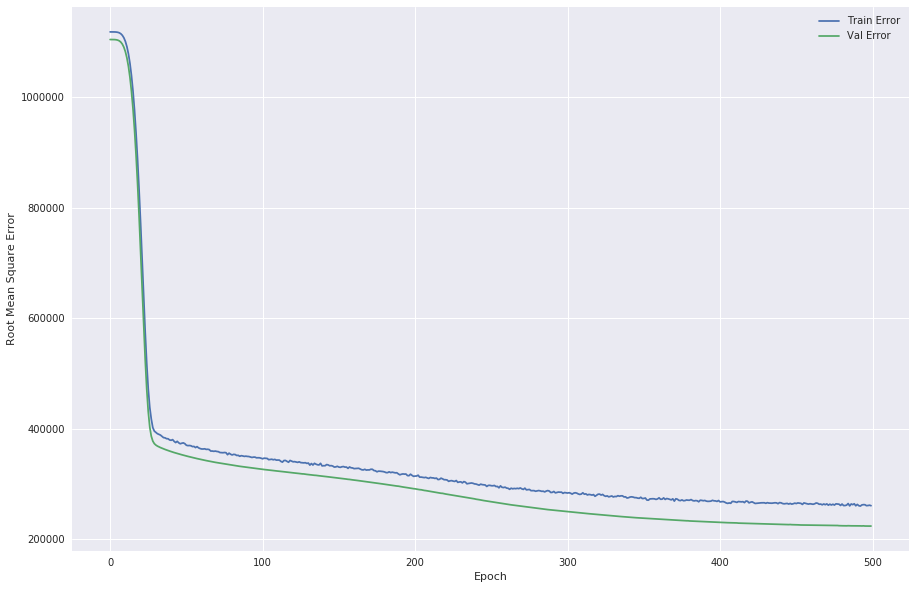

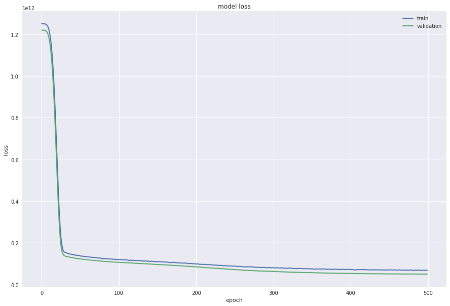

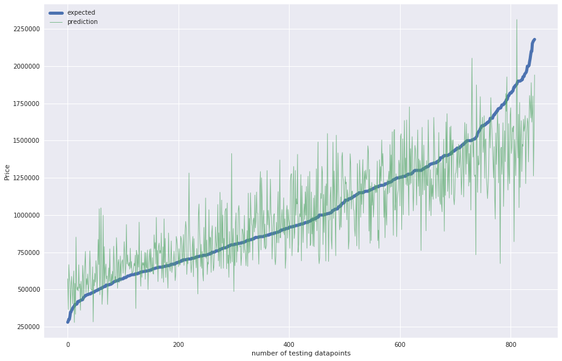

```
Fold #2
Fold score (RMSE): 255558.062
Fold #3
Fold score (RMSE): 244854.672
Fold #4
Fold score (RMSE): 249002.359
Fold #5
Fold score (RMSE): 235724.250
Fold #6
Fold score (RMSE): 230745.969
Fold #7
Fold score (RMSE): 245689.047
Fold #8
Fold score (RMSE): 256746.969
Fold #9
Fold score (RMSE): 244018.531
Fold #10
Fold score (RMSE): 257532.531
```

```python
# Using K-Fold cross validation with 10 folds
kf=KFold(10)
fold = 0

#out of sample lists
oos_y = []
oos_pred = []

#initializing min RSME
min_rmse=1e6

# trainig and validating the model using X_main (training data set)
for train, test in kf.split(X_main):
    fold+=1
    print("Fold #{}".format(fold))

    X_train_kf = X_main[train]
    y_train_kf = y_main[train]
    X_test_kf = X_main[test]
    y_test_kf = y_main[test]

    #Building a neural net
    model = Sequential()
    model.add(Dense(240, input_dim=X_main.shape[1], activation='relu'))
    model.add(Dropout(0.1))
    model.add(Dense(120, activation='relu'))
    model.add(Dropout(0.1))
    model.add(Dense(60, activation='relu'))
    model.add(Dropout(0.1))
    model.add(Dense(1, activation='linear'))

    model.compile(loss='mse', optimizer='Adam',metrics=['mse','mae'])
    model.optimizer.lr=0.001

    # model training
    history=model.fit(X_train_kf,y_train_kf,validation_data=(X_test_kf,y_test_kf), batch_size=500, verbose=0,epochs=500)

    # prediction on validating set
    pred = model.predict(X_test_kf)

    # building two lists: with real and predicted values
    oos_y.append(y_test_kf)
    oos_pred.append(pred)

    # Measure this fold's RMSE
    score = np.sqrt(mean_squared_error(y_test_kf,pred))
    print("Fold score (RMSE): {:.3f}".format(score))

    #Looking for the best NN and saving it to a file
    if score < min_rmse:
        # saving model to YAML
        model_yaml = model.to_yaml()
        with open("model.yaml", "w") as yaml_file:
            yaml_file.write(model_yaml)

        # saving weights to HDF5
        model.save_weights("model.h5")

        #updating min RMSE
        min_rmse = min(min_rmse,score)
        print("Min score (RMSE): {:.3f}".format(min_rmse))

        # ploting charts for new best model
        hist = pd.DataFrame(history.history)
        hist['epoch'] = history.epoch
        plot_history(hist)
        plotting_loss(history)
        chart_regression(pred.ravel(),y_test_kf.ravel())
```

### 4.3 RMSE based on all samples from training set

```python
# Build the prediction list out of all samples and calculate the error
oos_y = np.concatenate(oos_y)
oos_pred = np.concatenate(oos_pred)
score = np.sqrt(mean_squared_error(oos_y,oos_pred))
print(80*'=')
print("RMSE of all samples from training set: {:.3f}".format(score))
print(80*'=')
```

```
================================================================================
RMSE of all samples from training set: 244637.656
================================================================================
```

### 4.4 Reading parameters of the neural net with min-RMSE

```python
#loading the NN with the best weigts
yaml_file = open('model.yaml', 'r')
loaded_model_yaml = yaml_file.read()
yaml_file.close()
loaded_model = model_from_yaml(loaded_model_yaml)
# load weights into new model
loaded_model.load_weights("model.h5")
```

### 4.5 Validation of neral net on testing set

```python
# Prediction on unseen data (with loaded neural network)
holdout_pred = loaded_model.predict(X_holdout)
holdout_rmse = np.sqrt(mean_squared_error(y_holdout,holdout_pred))
holdout_r2_score = r2_score(y_holdout,holdout_pred)
print(80*'=')
print("RMSE of testing set: {:.3f}".format(holdout_rmse))
print("r2_score of testing set: {:.3f}".format(holdout_r2_score))
score_to_bm = 100*(bench_mod_score-holdout_r2_score)/bench_mod_score
rmse_to_bm = 100*(bench_mod_rmse-holdout_rmse)/bench_mod_rmse
print('Delta r_score to benchmark model: {:.1f}%'.format(score_to_bm))
print('Delta RMSE to benchmark model: {:.1f}%'.format(rmse_to_bm))
print(80*'=')
```

```
================================================================================
RMSE of testing set: 235927.672
r2_score of testing set: 0.677
Delta r_score to benchmark model: -14.2%
Delta RMSE to benchmark model: 10.9%
================================================================================
```

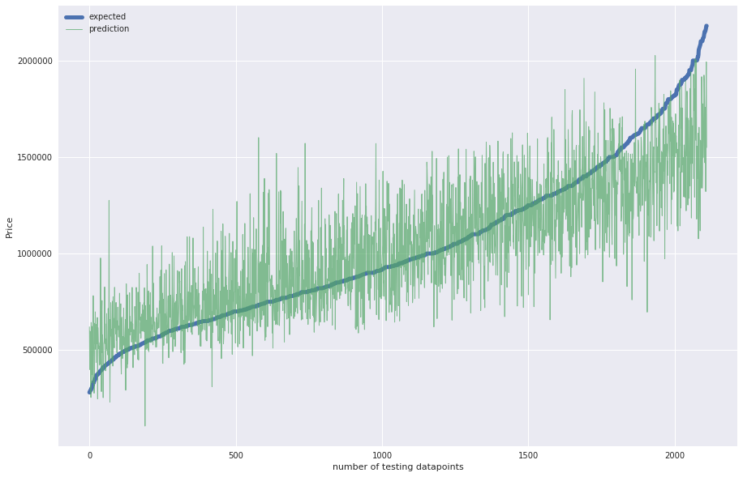

```python
# Plot shows how the neural net fits the target value
chart_regression(holdout_pred.ravel(),y_holdout.ravel())
```

## 5. Conclusion

```python
df_comp_bm = pd.DataFrame({'r2_score': [bench_mod_score, holdout_r2_score, score_xgb],
                           'rmse': [bench_mod_rmse, holdout_rmse, rmse_xgb]})
```

[figure not shown]

```python
# Create matplotlib figure
fig = plt.figure(figsize=(10,7))

# Create matplotlib axes
ax = fig.add_subplot(111)

# Create another axes that shares the same x-axis as ax.
ax2 = ax.twinx()

width = 0.2

df_comp_bm.r2_score.plot(kind='bar', color='red', ax=ax, width=width, position=0, label='score')
df_comp_bm.rmse.plot(kind='bar', color='blue', ax=ax2, width=width, position=1, label='rmse')

ax.set_ylabel('r2_score',  color='red', fontsize=17)
ax.tick_params('y', colors='red')
ax.tick_params('x', labelsize=17, rotation = 0)

ax2.set_ylabel('rmse', color='blue', fontsize=17)
ax2.tick_params('y', colors='blue')

plt.xticks(np.arange(3), ['Benchmark model', 'Neural net', 'GradientBoostingRegressor'], rotation=90)
plt.grid(b=False)
plt.tight_layout()
plt.show()
```